# Project 3 Q4-5

Tim Cook, Alex Poplawski, and T.J. Seislove

4/25/2026

# =================

# Exploratory Data Analysis

# =================

# a) Variable Exploration

#Distribution of Regular Season Scoring

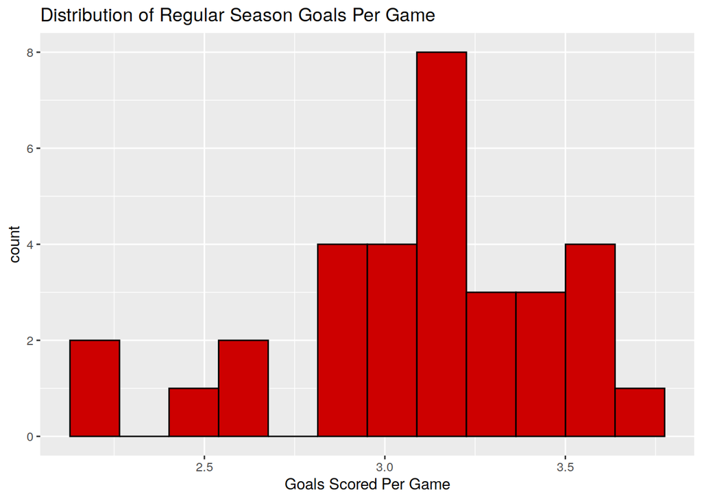

```r
ggplot(nhlreg, aes(x = `GF/G`)) + geom_histogram(bins = 12, fill = "red3", color = "black") +
    labs(title = "Distribution of Regular Season Goals Per Game", x = "Goals Scored Per Game")
```

```r
kable(nhlreg %>%
    summarize(Mean = mean(`GF/G`), SD = sd(`GF/G`), Median = median(`GF/G`)), caption = "Regular Season Scoring Summary")
```

Regular Season Scoring Summary

| Mean | SD | Median |
| --- | --- | --- |
| 3.081875 | 0.3789837 | 3.1 |

#Distribution of Playoff Win Percentage

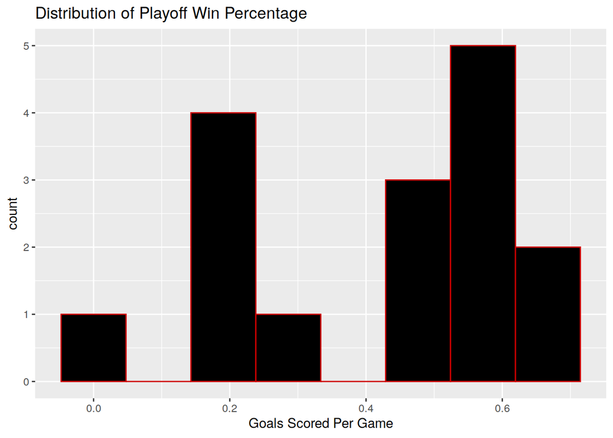

```r
ggplot(nhlpost, aes(x = `W-L%`)) + geom_histogram(bins = 8, fill = "black", color = "red3") +
    labs(title = "Distribution of Playoff Win Percentage", x = "Goals Scored Per Game",
        x = "Win-Loss %")
```

```r
kable(nhlpost %>%
    summarize(Mean = mean(`W-L%`), SD = sd(`W-L%`), Median = median(`W-L%`)), caption = "Post Season Win % Summary")
```

Post Season Win % Summary

| Mean | SD | Median |
| --- | --- | --- |
| 0.4061875 | 0.1946427 | 0.4455 |

# b) Primary & Foreign Keys

#Primary Key (Regular Season): Team. In the raw file, teams that made it to the playoffs had asterisks that I cleaned using str_remove to create the “Foreign Key.” #Primary Key (Playoffs): Team. These were the 16 teams that made it to the playoffs. #Compatability: By joining the two datasets based on Team, we can compare how the team did between the two facets of the season.

# =================

# Research Solutions

# =================

#Research Question

#We want to see if the team(s) that are super dominant in the regular season is just a trap when the playoffs roll around. So we want to see how strongly does a teams regular season points percentage predict their post season win percentage? We’re asking this because there is the ever going debate about if “regular season teams” (Dallas Cowboys in the NFL) struggle when the games become more decisive in the playoffs. We will use a linear model to see if the regular season standings actually matter once the playoffs begin.

#Analysis and Results

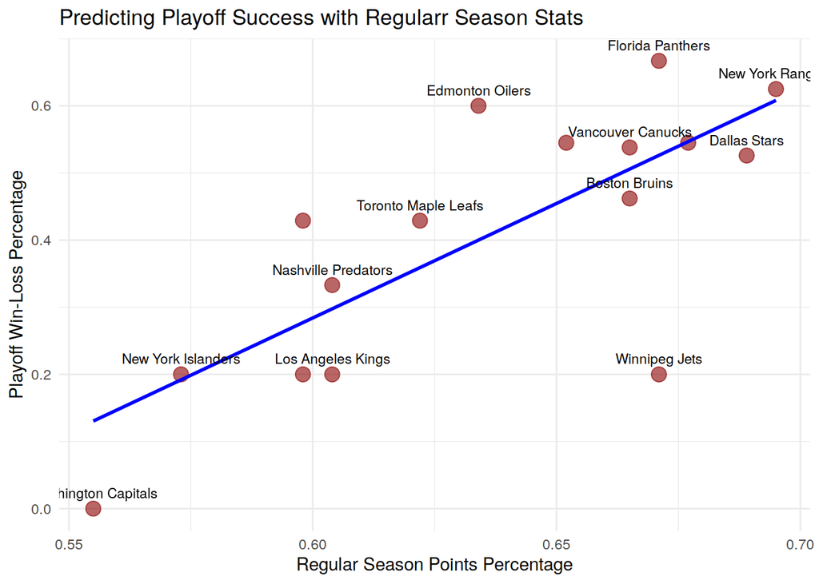

```r
ggplot(nhlcomb, aes(x = `PTS%`, y = `W-L%`)) + geom_point(size = 4, color = "darkred",
    alpha = 0.6) + geom_smooth(method = "lm", color = "blue", se = FALSE) + geom_text(aes(label = Team),
    check_overlap = TRUE, vjust = -1, size = 3) + labs(title = "Predicting Playoff Success with Regularr Season Stats",
    x = "Regular Season Points Percentage", y = "Playoff Win-Loss Percentage") +
    theme_minimal()
```

```r
kable(cor(nhlcomb$`PTS%`, nhlcomb$`W-L%`, use = "complete.obs"))
```

| x |
| --- |
| 0.7576796 |